# Linear Models in R

spsaaibi

March 02, 2015

# Ajustes de modelos lineales

En este archivo .Rmd exploraremos algunos usos del modelo lineal y los ajustes.

# Objetos cayendo

Usted es Galileo en el siglo XVI intentando describir la velocidad de los objetos cayendo. Su asistente, Giacomo, escala la torre inclinada de Pisa y arroja una pelota, mientras sus otros asistentes miden la posición de esas pelotas en distintos momentos del tiempo.

Simulemos esta situación, utilizando las ecuaciones cinemáticas que conocemos hoy y agregando un error de medición.

```r
set.seed(1)
g <- 9.8 ## m/s
n <- 25 ## numero de puntos
tt <- seq(0,3.4,len=n) ## tiempo en segundos

d <- 56.67  - 0.5*g*tt^2 + rnorm(n,sd=1)

df <- data.frame(d = d, tt = tt)
```

Los asistentes le dan los datos a galileo, y esto es lo que él observa:

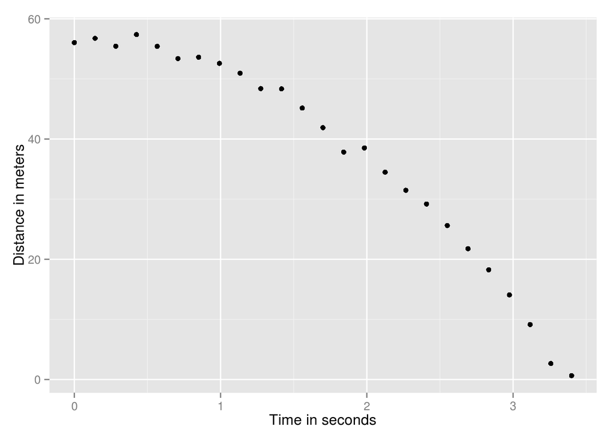

```r
ggplot(df) + geom_point(aes(x = tt, y = d)) + ylab("Distance in meters") + xlab("Time in seconds")
```

El no conoce la ecuación exacta, pero el intuye que pelota debe seguir una parábola, así que modela sus datos con la siguiente ecuación:

$Y_i = \beta_0 + \beta_1 x_i + \beta_2 x_i^2 + \varepsilon, i=1,\dots,n$

Donde $Y_i$ representa la posición, $x_i$ representa el tiempo, y $\varepsilon$ el error de medición. **Esto es un modelo lineal? Por qué?** (los $x$ s) son los predictores de los parámetros desconocidos (los $\beta$ s).

# Alturas de Padres e Hijos

Ahora, imagine que usted es Sir. Francis Galton en el siglo 19, y su pasatiempo es recopilar datos de estaturas de padres y sus hijos, pues usted sospecha que la altura es hereditaria.

```r
father.son <- read.table("http://stat-www.berkeley.edu/users/juliab/141C/pearson.dat")
library(UsingR)
names(father.son) <- c("fheight","sheight")
x=father.son$fheight
y=father.son$sheight
```

Al graficar, se ve lo siguiente:

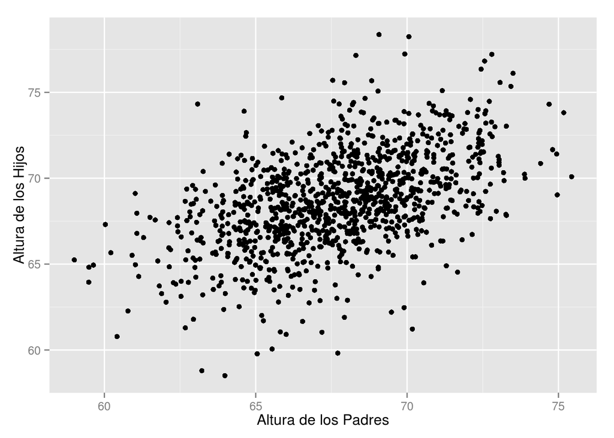

```r
ggplot(father.son) + geom_point(aes(x = fheight, y = sheight)) + xlab("Altura de los Padres") + ylab("Altura de los Hijos")
```

Usted tiene la brillante observación: *Parece haber una tendencia a que la altura de los hijos aumente de manera lineal con la altura de los padres*.

$Y_i = \beta_0 + \beta_1 x_i + \varepsilon, i=1,\dots,N$

Es decir, esto también se puede modelar con nuestro famoso modelo lineal. En este caso, $x_i$ y $Y_i$ son las alturas de los padres e hijos respectivamente para el $i$-ésimo par y $\varepsilon$un término de error para tener en cuenta variabilidad extra. En este caso, pensamos en la altura del padre como el predictor y lo dejamos fijo. Note que **las mediciones de error a solas no explican toda la variabilidad que se observa en $\varepsilon$**!. Esto tiene sentido, pues hay otras variables del modelo que no estamos teniendo en cuenta (altura de la madre, factores ambientales…)

# Modelo Lineal Generalizado

La siguiente ecuación muestra un modelo lineal general

$Y_i = \beta_0 + \beta_1 x_{i,1} + \beta_2 x_{i,2} + \dots + \beta_2 x_{i,p} \varepsilon_i, i=1,\dots,n$

$Y_i = \beta_0 + \sum_{j=1}^p \beta_j x_{i,j} + \varepsilon_i, i=1,\dots,n$

Con un número general de predictores $p$. El **álgebra matricial** provee un framework ideal y compacto para entender los modelos lineales de la manera expuesta anteriormente.

# Estimando parámetros

Todo el truco está en estimar los parámetros $\beta$. Para el ejemplo de Galileo, no tenemos idea de como son esos $\beta$. En el segundo, podemos hacer un estimado de como afecta la altura de los hijos la de los padres en promedio.

Un enfoque tradicional en ciencias, es encontrar valores que minimicen la distancia de l modelo ajustado a ciertos datos. Ese enfoque se conoce como Mínimos cuadrados.

$\sum_{i=1}^n \{ Y_i - (\beta_0 + \sum_{j=1}^p \beta_j x_{i,j}\}^2$

Una vez encontramos el mínimo, llamamos LSE a este estimado de los $\hat{\beta}$. Evaluando la ecuación de mínimos cuadrados en los estimados, encontramos el los mínimos residuos (RSS). Debido a que todas las cantidades dependen de $Y$, son *variables aleatorias*.

## Objetos cayendo, nuevamente

Segun la física de colegio, sabemos que:

$d = h_0 + v_0 t - 0.5 \times 9.8 t^2$

Con $h_0$ y $v_0$ altura y velocidad inicial. Los datos que simulamos arriba, asumen velocidad inicial cero $(v_0=0)$ desde la torre inclinada de Pisa $(h_0=56.67)$. Acá ponemos el código para recordar:

```r
g <- 9.8 ## meters per second
n <- 25
tt <- seq(0,3.4,len=n) ##time in secs, t is a base function
f <- 56.67  - 0.5*g*tt^2
y <-  f + rnorm(n,sd=1)
```

Estos son los datos unidos con una línea sólida:

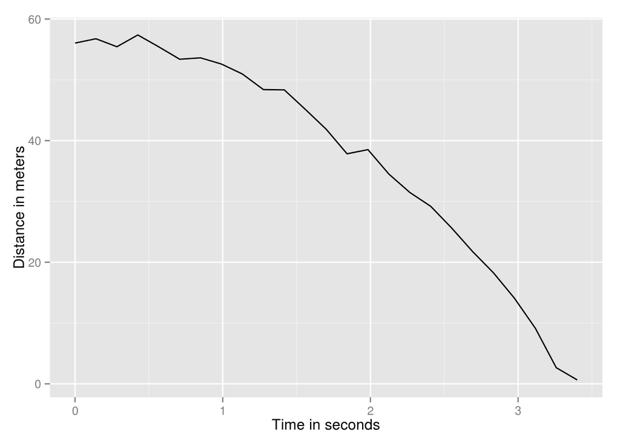

```r
ggplot(df) + geom_line(aes(x = tt, y = d)) + ylab("Distance in meters") + xlab("Time in seconds")
```

Pero como somos galileo, no conocemos esa ecuación. Solo tenemos este modelo lineal y queremos encontrar el LSE.

$Y_i = \beta_0 + \beta_1 x_i + \beta_2 x_i^2 + \varepsilon, i=1,\dots,n$

## La función `lm` en R

En R podemos hacer ajustes lineales con la función `lm`. una vista previa de la función:

```r
tt2 <-tt^2
fit <- lm(y~tt+tt2)
summary(fit)$coef
```

```
##               Estimate Std. Error    t value     Pr(>|t|)
## (Intercept) 56.4305502  0.3969358 142.165421 4.226652e-34
## tt           0.1467666  0.5407103   0.271433 7.885888e-01
## tt2         -4.8943619  0.1536079 -31.862690 6.638629e-20
```

Obtenemos el LSE, errores estandar y p-values.

**Cuál es la justificación matemática detrás de esta ecuación?**

## Calculando el LSE/RSS

Escribamos una función que calcule el RSS para cualquier vector de $\beta$

```r
rss <- function(Beta0,Beta1,Beta2){
  r <- y - (Beta0+Beta1*tt+Beta2*tt^2)
  return(sum(r^2))
}
```

Entonces, para cualquier vector de 3 dimensiones, obtenemos un rss. Acá una representación gráfica de RSS en función de $\beta_2$ manteniendo los otros betas fijos:

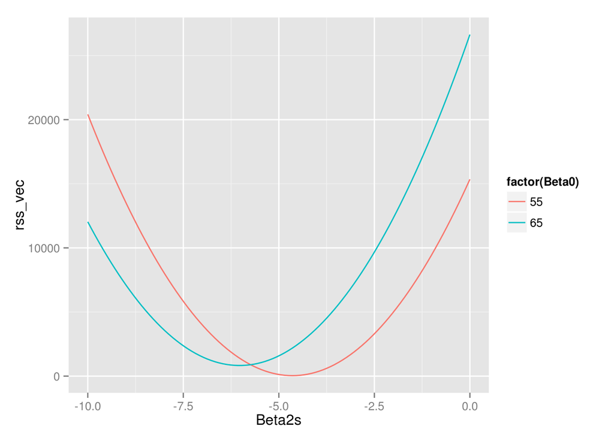

```r
Beta2s<- seq(-10,0,len=100)
Beta0 <- 55
Beta1 <- 0
rss_vec = sapply(Beta2s,rss,Beta0=Beta0,Beta1=Beta1)

ddf <- data.frame(Beta2s= Beta2s, rss_vec = rss_vec,Beta0 = Beta0, Beta1 = Beta1)

Beta0 <- 65
Beta1 <- 0
rss_vec = sapply(Beta2s,rss,Beta0=Beta0,Beta1=Beta1)

ddf <- rbind(ddf, data.frame(Beta2s= Beta2s, rss_vec = rss_vec,Beta0 = Beta0, Beta1 = Beta1))

ggplot(ddf) + geom_line(aes(x = Beta2s, y = rss_vec, color = factor(Beta0)))
```

```r
## Agreguemos otra curva (para otro par de puntos)
```

Cómo se soluciona el mejor ajuste para estos parámetros?

Prueba y error? NO!

Tome derivadas parciales, iguale a cero y resuelva el sistema. Y que pasa si son MUCHAS ecuaciones?

Use álgebra lineal.

## Interpolación

A continuación el dataset mtcars:

```r
str(mtcars)
```

```
## 'data.frame':    32 obs. of  11 variables:
##  $ mpg : num  21 21 22.8 21.4 18.7 18.1 14.3 24.4 22.8 19.2 ...
##  $ cyl : num  6 6 4 6 8 6 8 4 4 6 ...
##  $ disp: num  160 160 108 258 360 ...
##  $ hp  : num  110 110 93 110 175 105 245 62 95 123 ...
##  $ drat: num  3.9 3.9 3.85 3.08 3.15 2.76 3.21 3.69 3.92 3.92 ...
##  $ wt  : num  2.62 2.88 2.32 3.21 3.44 ...
##  $ qsec: num  16.5 17 18.6 19.4 17 ...
##  $ vs  : num  0 0 1 1 0 1 0 1 1 1 ...
##  $ am  : num  1 1 1 0 0 0 0 0 0 0 ...
##  $ gear: num  4 4 4 3 3 3 3 4 4 4 ...
##  $ carb: num  4 4 1 1 2 1 4 2 2 4 ...
```

Grafiquemos:

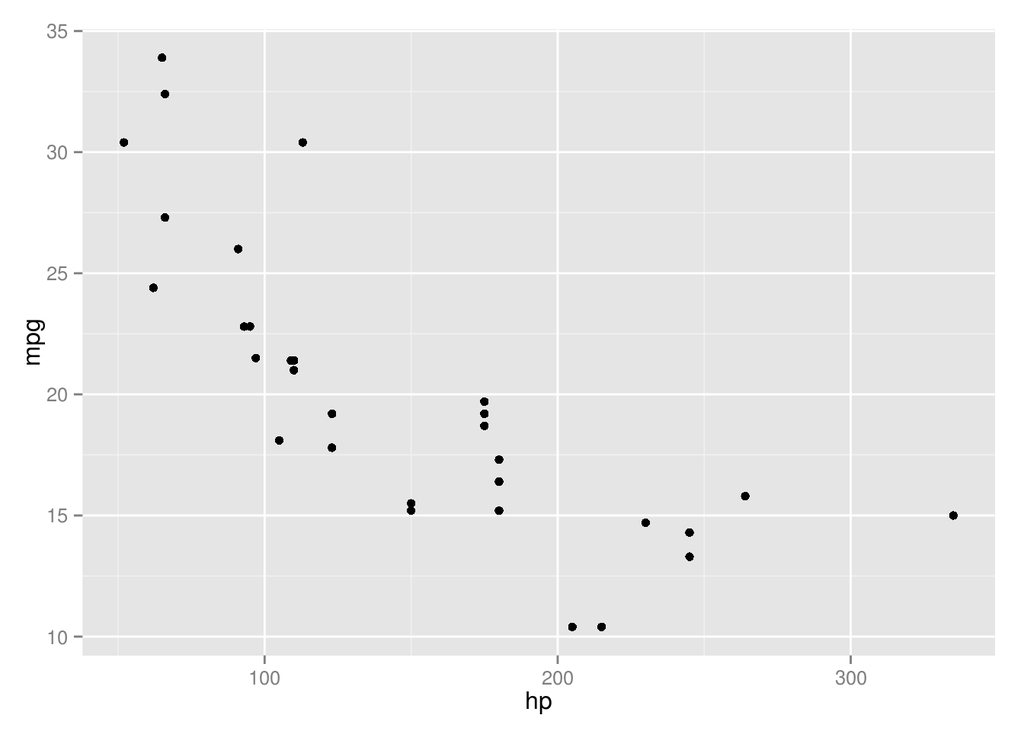

Ahora, ajustemos una curva y~x

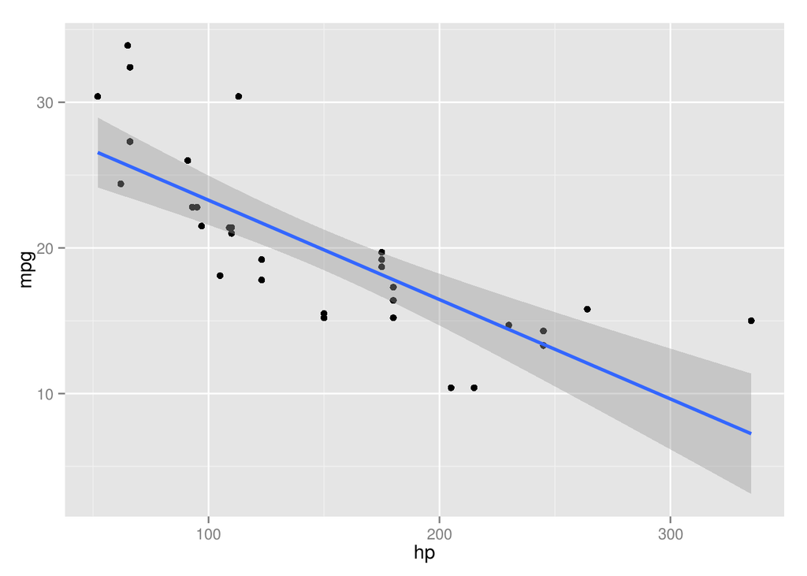

Ahora, busquemos un ajuste variable con pesos:

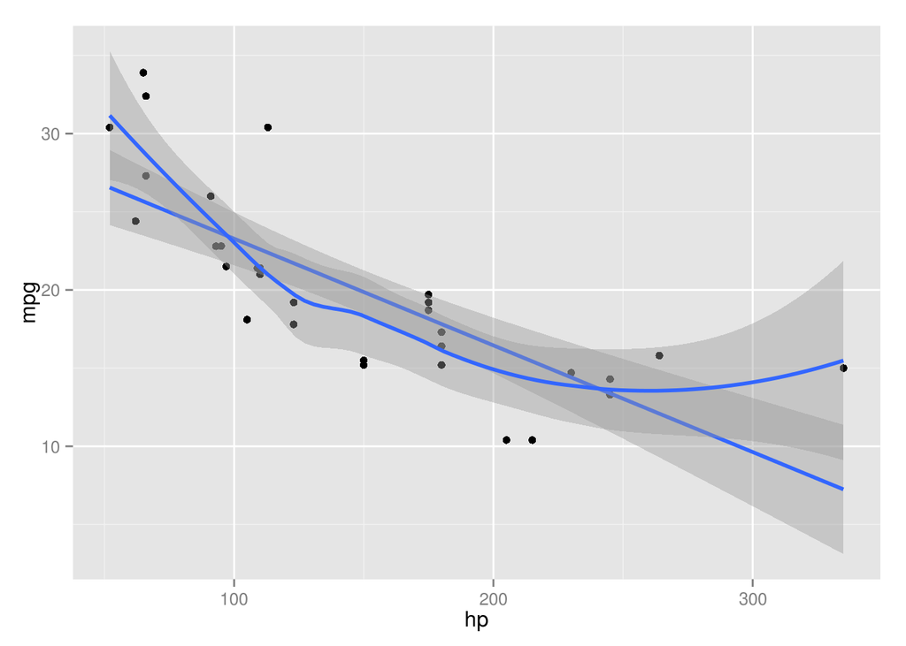

También podemos intentar con modelos aditivos generalizados:

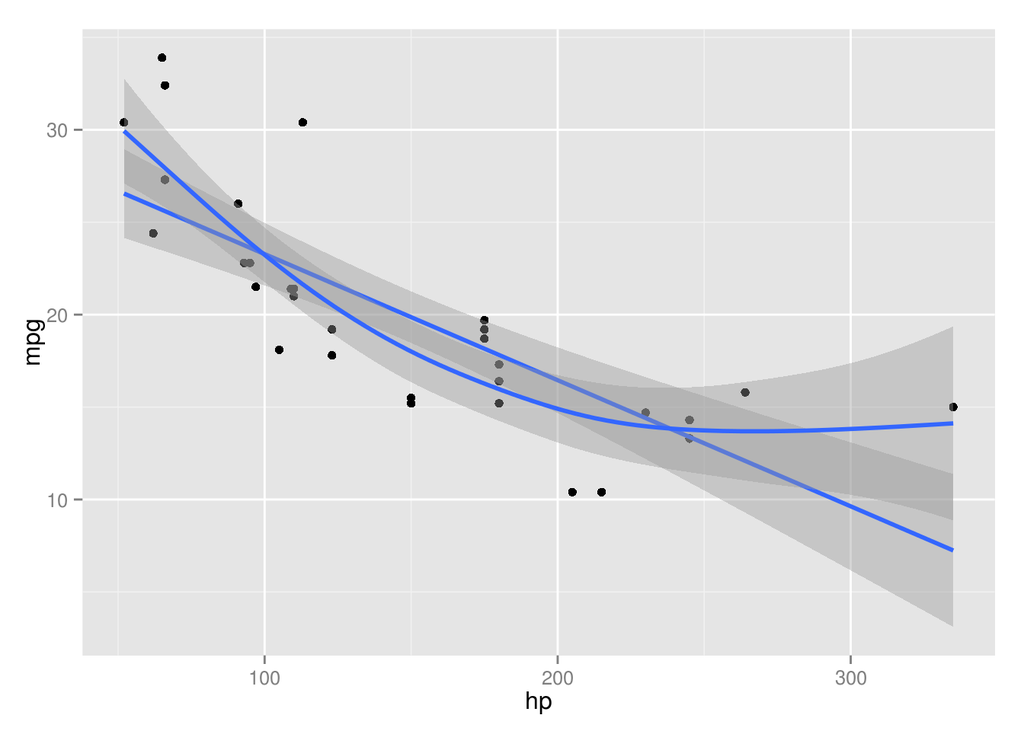